# Tools Comparison (Simple): Claude Code + Opus 4.6

## Run Metadata

- Harness: `claude-code`
- Model: `opus-4-6`
- Prompt type: `simple`

## Setup

```r
library(dplyr)

df <- readr::read_csv(here::here("data/synthetic/simulated_maternal_health_data.csv"))
```

## Prompt

```
Study this data set (`data/synthetic/simulated_maternal_health_data.csv`), show me descriptive statistics, pick a modeling strategy, and report the model. Be thorough.
```

## Response

### Dataset Overview

The dataset contains 50,000 observations across 20 variables tracking maternal health outcomes. The binary outcome variable is `received_comprehensive_postnatal_care` (0/1), with a base rate of approximately 32.3%. Predictors span four domains:

- **Demographics**: age (15–44), race/ethnicity (7 groups), state (51 values)
- **Socioeconomic**: self-reported income (8 brackets), education (5 levels), insurance (3 types), job type (4 categories), number of dependents (0–8)
- **Access**: distance to provider (0–163 miles)
- **Clinical comorbidities**: 8 binary indicators (obesity, multiple gestation, diabetes, heart disease, placenta previa, hypertension, gestational hypertension, preeclampsia)

### Descriptive Statistics

```r
glimpse(df)
```

```
Rows: 50,000
Columns: 20
$ id                                    <dbl> 1, 2, 3, 4, 5, 6, 7, 8, 9, 10, 1…
$ provider_id                           <dbl> 1, 1, 1, 1, 1, 1, 1, 1, 1, 1, 1,…
$ state                                 <chr> "AK", "AK", "AK", "AK", "AK", "A…
$ received_comprehensive_postnatal_care <dbl> 0, 1, 0, 0, 0, 1, 1, 1, 0, 0, 0,…
$ self_report_income                    <chr> "$50,000–$74,999", "$50,000–$74,…
$ age                                   <dbl> 31, 26, 33, 37, 21, 33, 25, 34, …
$ edu                                   <chr> "hs", "hs", "some_college", "hs"…
$ race_ethnicity                        <chr> "white", "white", "white", "asia…
$ insurance                             <chr> "no_insurance", "no_insurance", …
$ job_type                              <chr> "unskilled", "unskilled", "unski…
$ dependents                            <dbl> 2, 2, 2, 2, 2, 2, 2, 3, 3, 3, 3,…
$ distance_to_provider                  <dbl> 1.7889754, 10.8991396, 35.122047…
$ obesity                               <dbl> 0, 0, 1, 0, 1, 1, 1, 1, 1, 1, 0,…
$ multiple_gestation                    <dbl> 0, 0, 0, 0, 0, 1, 0, 1, 0, 0, 0,…
$ diabetes                              <dbl> 0, 0, 0, 0, 0, 0, 0, 0, 0, 0, 0,…
$ heart_disease                         <dbl> 0, 0, 0, 1, 0, 0, 1, 0, 0, 0, 0,…
$ placenta_previa                       <dbl> 0, 0, 0, 0, 0, 0, 0, 0, 0, 0, 0,…
$ hypertension                          <dbl> 0, 0, 1, 0, 0, 1, 0, 0, 0, 0, 0,…
$ gest_hypertension                     <dbl> 0, 0, 0, 0, 0, 0, 0, 0, 0, 0, 0,…
$ preeclampsia                          <dbl> 0, 0, 0, 0, 0, 0, 0, 0, 0, 0, 0,…
```

```r
df |>
  count(received_comprehensive_postnatal_care) |>
  mutate(pct = round(n / sum(n) * 100, 1))
```

```
# A tibble: 2 × 3
  received_comprehensive_postnatal_care     n   pct
                                  <dbl> <int> <dbl>
1                                     0 33851  67.7
2                                     1 16149  32.3
```

```r
df |>
  select(age, dependents, distance_to_provider) |>
  summary()
```

```
      age          dependents    distance_to_provider
 Min.   :15.00   Min.   :0.000   Min.   :8.900e-05
 1st Qu.:23.00   1st Qu.:2.000   1st Qu.:4.096e+00
 Median :28.00   Median :2.000   Median :1.000e+01
 Mean   :28.02   Mean   :2.382   Mean   :1.452e+01
 3rd Qu.:32.00   3rd Qu.:3.000   3rd Qu.:2.024e+01
 Max.   :44.00   Max.   :8.000   Max.   :1.634e+02
```

```r
cat_vars <- c("self_report_income", "edu", "race_ethnicity", "insurance", "job_type")

for (v in cat_vars) {
  cat("\n---", v, "---\n")
  print(
    df |>
      count(.data[[v]], received_comprehensive_postnatal_care) |>
      group_by(.data[[v]]) |>
      mutate(pct = round(n / sum(n) * 100, 1)) |>
      ungroup()
  )
}
```

```
--- self_report_income ---
# A tibble: 16 × 4
   self_report_income received_comprehensive_postnatal_care     n   pct
   <chr>                                              <dbl> <int> <dbl>
 1 $0–$24,999                                             0   440  72.5
 2 $0–$24,999                                             1   167  27.5
 3 $100,000–$124,999                                      0  1741  64
 4 $100,000–$124,999                                      1   979  36
 5 $125,000–$149,999                                      0   432  64.8
 6 $125,000–$149,999                                      1   235  35.2
 7 $150,000–$174,999                                      0   109  63.7
 8 $150,000–$174,999                                      1    62  36.3
 9 $175,000+                                              0    41  66.1
10 $175,000+                                              1    21  33.9
11 $25,000–$49,999                                        0 10147  69
12 $25,000–$49,999                                        1  4563  31
13 $50,000–$74,999                                        0 14449  67.9
14 $50,000–$74,999                                        1  6830  32.1
15 $75,000–$99,999                                        0  6492  66.4
16 $75,000–$99,999                                        1  3292  33.6

--- edu ---
# A tibble: 10 × 4
   edu          received_comprehensive_postnatal_care     n   pct
   <chr>                                        <dbl> <int> <dbl>
 1 college                                          0  3447  65.4
 2 college                                          1  1822  34.6
 3 hs                                               0 15818  68.5
 4 hs                                               1  7290  31.5
 5 less_than_hs                                     0  3628  69.5
 6 less_than_hs                                     1  1590  30.5
 7 post_grad                                        0   938  64.9
 8 post_grad                                        1   508  35.1
 9 some_college                                     0 10020  67
10 some_college                                     1  4939  33

--- race_ethnicity ---
# A tibble: 14 × 4
   race_ethnicity received_comprehensive_postnatal_care     n   pct
   <chr>                                          <dbl> <int> <dbl>
```

[output cut: 23 more lines]

```
5 state_provided                                     0  7656  67.9
6 state_provided                                     1  3626  32.1

--- job_type ---
# A tibble: 8 × 4
  job_type     received_comprehensive_postnatal_care     n   pct
  <chr>                                        <dbl> <int> <dbl>
1 professional                                     0  9157  64.1
2 professional                                     1  5136  35.9
3 trade                                            0  4130  65.6
4 trade                                            1  2168  34.4
5 unemployed                                       0  1520  68.6
6 unemployed                                       1   697  31.4
7 unskilled                                        0 19044  70
8 unskilled                                        1  8148  30
```

```r
comorbidities <- c("obesity", "multiple_gestation", "diabetes", "heart_disease",
                   "placenta_previa", "hypertension", "gest_hypertension", "preeclampsia")

df |>
  select(all_of(comorbidities)) |>
  summarise(across(everything(), \(x) round(mean(x) * 100, 1))) |>
  pivot_longer(everything(), names_to = "condition", values_to = "prevalence_pct") |>
  arrange(desc(prevalence_pct))
```

```
# A tibble: 8 × 2
  condition          prevalence_pct
  <chr>                       <dbl>
1 obesity                        35
2 hypertension                   20
3 heart_disease                  15
4 diabetes                       10
5 gest_hypertension               5
6 multiple_gestation              3
7 preeclampsia                    2
8 placenta_previa                 1
```

#### Visualizations

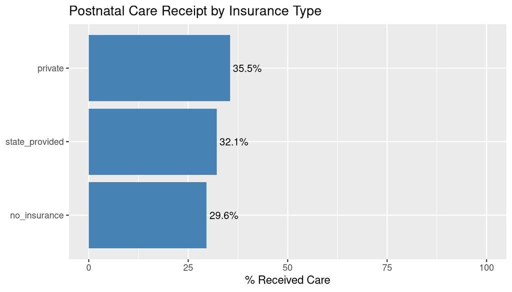

```r
df |>
  group_by(insurance) |>
  summarise(pct_care = mean(received_comprehensive_postnatal_care) * 100,
            n = n()) |>
  ggplot(aes(x = reorder(insurance, pct_care), y = pct_care)) +
  geom_col(fill = "steelblue") +
  geom_text(aes(label = sprintf("%.1f%%", pct_care)), hjust = -0.1, size = 3.5) +
  coord_flip() +
  labs(title = "Postnatal Care Receipt by Insurance Type",
       x = NULL, y = "% Received Care") +
  ylim(0, 100)
```

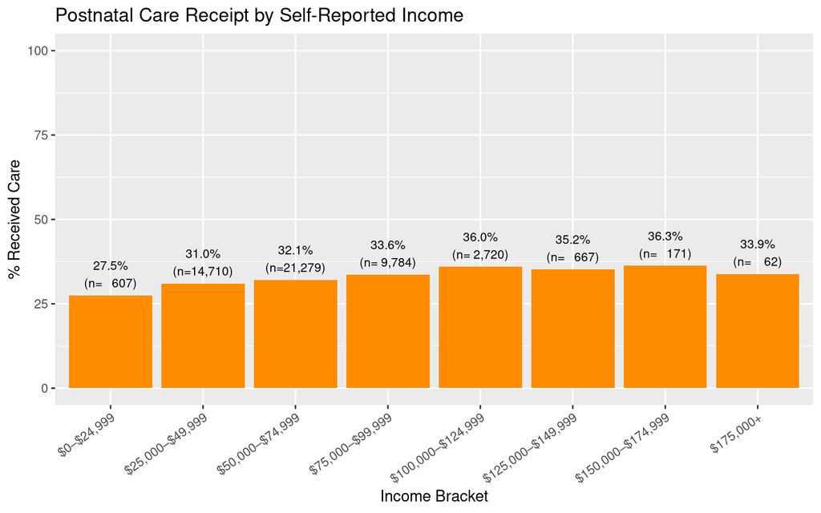

```r
income_order <- c("$0–$24,999", "$25,000–$49,999", "$50,000–$74,999",
                  "$75,000–$99,999", "$100,000–$124,999", "$125,000–$149,999",
                  "$150,000–$174,999", "$175,000+")

df |>
  group_by(self_report_income) |>
  summarise(pct_care = mean(received_comprehensive_postnatal_care) * 100,
            n = n()) |>
  mutate(self_report_income = factor(self_report_income, levels = income_order)) |>
  ggplot(aes(x = self_report_income, y = pct_care)) +
  geom_col(fill = "darkorange") +
  geom_text(aes(label = sprintf("%.1f%%\n(n=%s)", pct_care, format(n, big.mark = ","))),
            vjust = -0.3, size = 3) +
  labs(title = "Postnatal Care Receipt by Self-Reported Income",
       x = "Income Bracket", y = "% Received Care") +
  theme(axis.text.x = element_text(angle = 35, hjust = 1)) +
  ylim(0, 100)
```

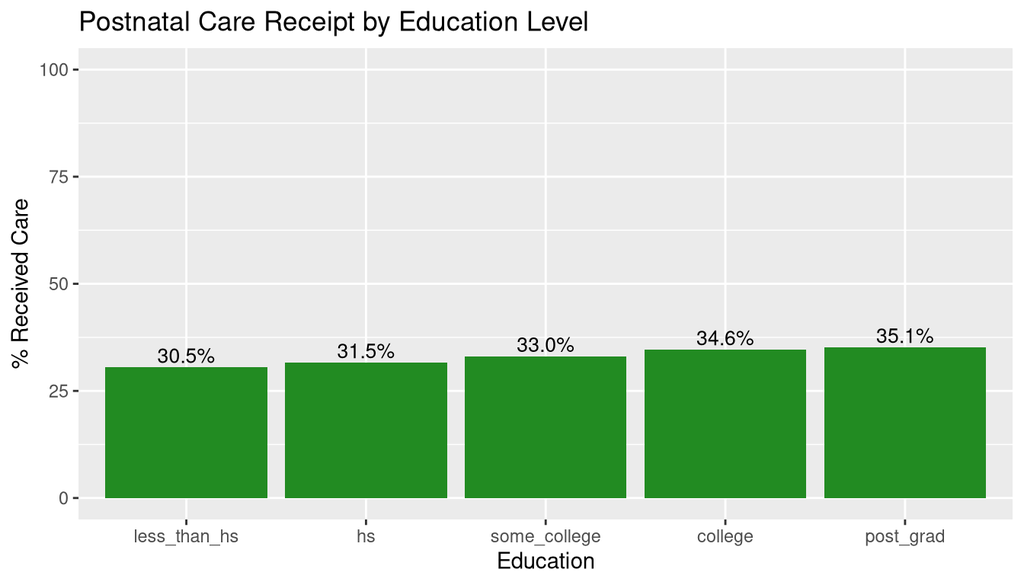

```r
edu_order <- c("less_than_hs", "hs", "some_college", "college", "post_grad")

df |>
  group_by(edu) |>
  summarise(pct_care = mean(received_comprehensive_postnatal_care) * 100,
            n = n()) |>
  mutate(edu = factor(edu, levels = edu_order)) |>
  ggplot(aes(x = edu, y = pct_care)) +
  geom_col(fill = "forestgreen") +
  geom_text(aes(label = sprintf("%.1f%%", pct_care)), vjust = -0.3, size = 3.5) +
  labs(title = "Postnatal Care Receipt by Education Level",
       x = "Education", y = "% Received Care") +
  ylim(0, 100)
```

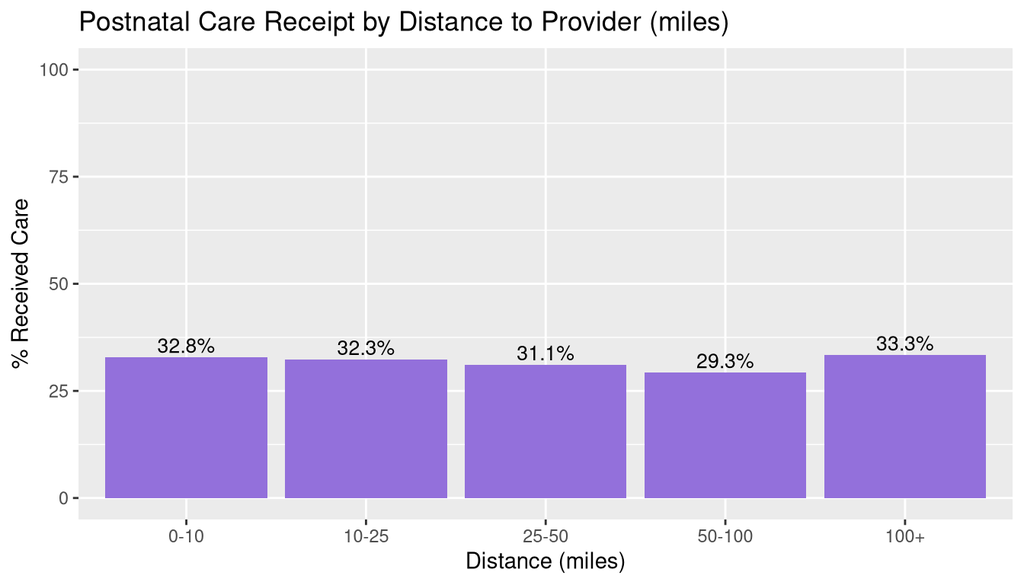

```r
df |>
  mutate(dist_bin = cut(distance_to_provider,
                        breaks = c(0, 10, 25, 50, 100, Inf),
                        labels = c("0-10", "10-25", "25-50", "50-100", "100+"),
                        include.lowest = TRUE)) |>
  group_by(dist_bin) |>
  summarise(pct_care = mean(received_comprehensive_postnatal_care) * 100,
            n = n()) |>
  ggplot(aes(x = dist_bin, y = pct_care)) +
  geom_col(fill = "mediumpurple") +
  geom_text(aes(label = sprintf("%.1f%%", pct_care)), vjust = -0.3, size = 3.5) +
  labs(title = "Postnatal Care Receipt by Distance to Provider (miles)",
       x = "Distance (miles)", y = "% Received Care") +
  ylim(0, 100)
```

### Modeling Strategy

The outcome is binary, so **logistic regression** is the appropriate starting point. Reasons for this choice:

1. **Interpretability**: Produces odds ratios with direct clinical and policy relevance.
2. **Handles mixed predictor types**: Accommodates continuous variables (age, distance, dependents) alongside multi-level categorical predictors (income, education, race/ethnicity, insurance, job type).
3. **Large sample**: With n = 50,000, asymptotic assumptions are well satisfied, and we have ample power to detect moderate effects.

I exclude `id`, `provider_id`, and `state` from the model. Provider and state could introduce hundreds of parameters and are better handled through mixed-effects models or fixed-effect adjustments in a more targeted analysis. All remaining predictors are included.

### Model

```r
edu_levels <- c("less_than_hs", "hs", "some_college", "college", "post_grad")

df_model <- df |>
  mutate(
    edu = factor(edu, levels = edu_levels),
    insurance = factor(insurance, levels = c("no_insurance", "state_provided", "private")),
    job_type = factor(job_type, levels = c("unemployed", "unskilled", "trade", "professional")),
    self_report_income = factor(self_report_income, levels = income_order),
    race_ethnicity = factor(race_ethnicity)
  )
```

```r
fit <- glm(
  received_comprehensive_postnatal_care ~
    age + self_report_income + edu + race_ethnicity + insurance + job_type +
    dependents + distance_to_provider +
    obesity + multiple_gestation + diabetes + heart_disease +
    placenta_previa + hypertension + gest_hypertension + preeclampsia,
  data = df_model,
  family = binomial(link = "logit")
)

summary(fit)
```

```
Call:
glm(formula = received_comprehensive_postnatal_care ~ age + self_report_income +
    edu + race_ethnicity + insurance + job_type + dependents +
    distance_to_provider + obesity + multiple_gestation + diabetes +
    heart_disease + placenta_previa + hypertension + gest_hypertension +
    preeclampsia, family = binomial(link = "logit"), data = df_model)

Coefficients:
                                      Estimate Std. Error z value Pr(>|z|)
(Intercept)                         -1.3755848  0.1674200  -8.216  < 2e-16 ***
age                                 -0.0033388  0.0016418  -2.034 0.041994 *
self_report_income$25,000–$49,999    0.1686885  0.0929534   1.815 0.069560 .
self_report_income$50,000–$74,999    0.2180526  0.0924406   2.359 0.018332 *
self_report_income$75,000–$99,999    0.2862065  0.0937998   3.051 0.002279 **
self_report_income$100,000–$124,999  0.3908898  0.0998203   3.916 9.01e-05 ***
self_report_income$125,000–$149,999  0.3566258  0.1224428   2.913 0.003584 **
self_report_income$150,000–$174,999  0.3827328  0.1840644   2.079 0.037586 *
self_report_income$175,000+          0.2889439  0.2843634   1.016 0.309578
eduhs                                0.0129963  0.0346140   0.375 0.707315
edusome_college                      0.0293892  0.0374577   0.785 0.432690
educollege                           0.0516587  0.0451628   1.144 0.252693
edupost_grad                         0.0300470  0.0662745   0.453 0.650280
race_ethnicityasian                  0.5022155  0.1271457   3.950 7.82e-05 ***
race_ethnicityblack                  0.2699720  0.1246028   2.167 0.030261 *
race_ethnicityhispanic               0.4093269  0.1233554   3.318 0.000906 ***
race_ethnicitynhpi                   0.6329030  0.2507780   2.524 0.011611 *
race_ethnicityother                  0.2634611  0.1791710   1.470 0.141441
race_ethnicitywhite                  0.4989423  0.1217629   4.098 4.17e-05 ***
insurancestate_provided              0.1196448  0.0258611   4.626 3.72e-06 ***
insuranceprivate                     0.1917152  0.0251509   7.623 2.49e-14 ***
job_typeunskilled                   -0.0938354  0.0501907  -1.870 0.061543 .
job_typetrade                        0.0704684  0.0570203   1.236 0.216516
job_typeprofessional                 0.0654753  0.0580130   1.129 0.259054
dependents                          -0.0176272  0.0120080  -1.468 0.142115
distance_to_provider                -0.0025194  0.0006686  -3.768 0.000164 ***
obesity                             -0.0229207  0.0211138  -1.086 0.277666
multiple_gestation                  -0.0251224  0.0596085  -0.421 0.673422
diabetes                             0.1105601  0.0319893   3.456 0.000548 ***
heart_disease                        0.0980841  0.0267423   3.668 0.000245 ***
placenta_previa                      0.0707850  0.0980195   0.722 0.470201
hypertension                         0.0574139  0.0250683   2.290 0.022004 *
gest_hypertension                   -0.0095485  0.0452061  -0.211 0.832714
preeclampsia                         0.0615993  0.0695953   0.885 0.376099
---
Signif. codes:  0 '***' 0.001 '**' 0.01 '*' 0.05 '.' 0.1 ' ' 1

(Dispersion parameter for binomial family taken to be 1)

    Null deviance: 62910  on 49999  degrees of freedom
Residual deviance: 62501  on 49966  degrees of freedom
AIC: 62569

Number of Fisher Scoring iterations: 4
```

```r
or_table <- broom::tidy(fit, exponentiate = TRUE, conf.int = TRUE) |>
  filter(term != "(Intercept)") |>
  mutate(across(c(estimate, conf.low, conf.high), \(x) round(x, 3)),
         p.value = round(p.value, 4)) |>
  select(term, OR = estimate, CI_low = conf.low, CI_high = conf.high, p.value)

knitr::kable(or_table,
             caption = "Odds Ratios for Receiving Comprehensive Postnatal Care")
```

Odds Ratios for Receiving Comprehensive Postnatal Care

| term | OR | CI_low | CI_high | p.value |
| --- | --- | --- | --- | --- |
| age | 0.997 | 0.993 | 1.000 | 0.0420 |
| self_report_income$25,000–$49,999 | 1.184 | 0.989 | 1.424 | 0.0696 |
| self_report_income$50,000–$74,999 | 1.244 | 1.040 | 1.494 | 0.0183 |
| self_report_income$75,000–$99,999 | 1.331 | 1.110 | 1.604 | 0.0023 |
| self_report_income$100,000–$124,999 | 1.478 | 1.218 | 1.801 | 0.0001 |
| self_report_income$125,000–$149,999 | 1.429 | 1.124 | 1.818 | 0.0036 |
| self_report_income$150,000–$174,999 | 1.466 | 1.019 | 2.098 | 0.0376 |
| self_report_income$175,000+ | 1.335 | 0.753 | 2.307 | 0.3096 |
| eduhs | 1.013 | 0.947 | 1.084 | 0.7073 |
| edusome_college | 1.030 | 0.957 | 1.108 | 0.4327 |
| educollege | 1.053 | 0.964 | 1.151 | 0.2527 |
| edupost_grad | 1.031 | 0.905 | 1.173 | 0.6503 |
| race_ethnicityasian | 1.652 | 1.293 | 2.130 | 0.0001 |
| race_ethnicityblack | 1.310 | 1.031 | 1.681 | 0.0303 |
| race_ethnicityhispanic | 1.506 | 1.188 | 1.928 | 0.0009 |
| race_ethnicitynhpi | 1.883 | 1.145 | 3.067 | 0.0116 |
| race_ethnicityother | 1.301 | 0.915 | 1.849 | 0.1414 |
| race_ethnicitywhite | 1.647 | 1.303 | 2.102 | 0.0000 |
| insurancestate_provided | 1.127 | 1.071 | 1.186 | 0.0000 |
| insuranceprivate | 1.211 | 1.153 | 1.273 | 0.0000 |
| job_typeunskilled | 0.910 | 0.825 | 1.005 | 0.0615 |
| job_typetrade | 1.073 | 0.960 | 1.200 | 0.2165 |
| job_typeprofessional | 1.068 | 0.953 | 1.197 | 0.2591 |
| dependents | 0.983 | 0.960 | 1.006 | 0.1421 |
| distance_to_provider | 0.997 | 0.996 | 0.999 | 0.0002 |
| obesity | 0.977 | 0.938 | 1.019 | 0.2777 |
| multiple_gestation | 0.975 | 0.867 | 1.095 | 0.6734 |
| diabetes | 1.117 | 1.049 | 1.189 | 0.0005 |
| heart_disease | 1.103 | 1.047 | 1.162 | 0.0002 |
| placenta_previa | 1.073 | 0.884 | 1.299 | 0.4702 |
| hypertension | 1.059 | 1.008 | 1.112 | 0.0220 |
| gest_hypertension | 0.990 | 0.906 | 1.082 | 0.8327 |
| preeclampsia | 1.064 | 0.927 | 1.218 | 0.3761 |

```r
cat("AIC:", AIC(fit), "\n")
```

```
AIC: 62569.08
```

```r
cat("Null deviance:", fit$null.deviance, "on", fit$df.null, "df\n")
```

```
Null deviance: 62909.53 on 49999 df
```

```r
cat("Residual deviance:", fit$deviance, "on", fit$df.residual, "df\n")
```

```
Residual deviance: 62501.08 on 49966 df
```

```r
cat("McFadden pseudo-R²:", round(1 - fit$deviance / fit$null.deviance, 4), "\n")
```

```
McFadden pseudo-R²: 0.0065
```

```
`height` was translated to `width`.
```

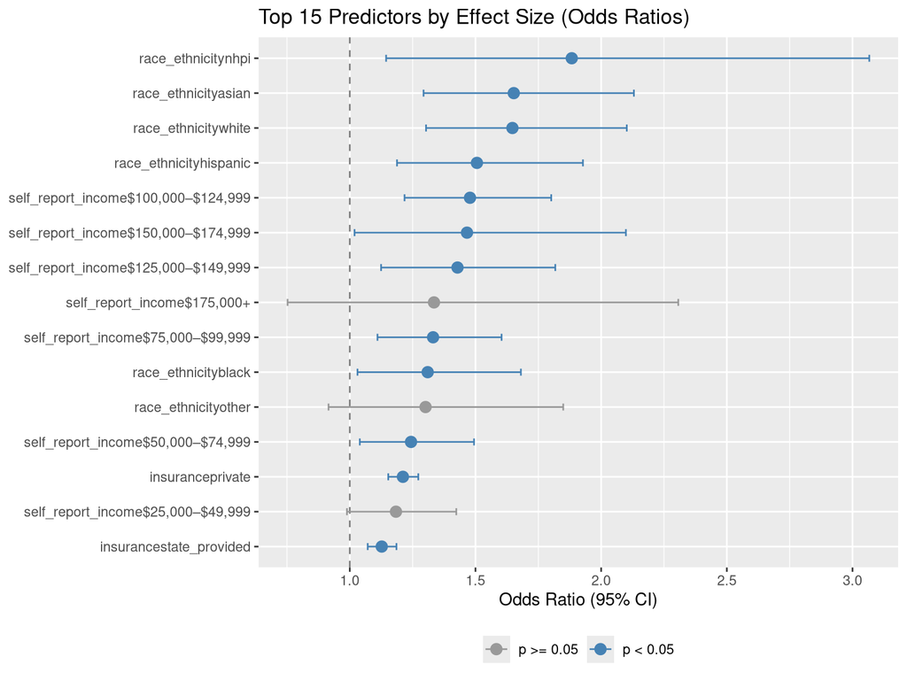

```r
or_plot <- broom::tidy(fit, exponentiate = TRUE, conf.int = TRUE) |>
  filter(term != "(Intercept)") |>
  mutate(significant = p.value < 0.05) |>
  arrange(desc(abs(log(estimate)))) |>
  slice_head(n = 15) |>
  mutate(term = forcats::fct_reorder(term, estimate))

ggplot(or_plot, aes(x = estimate, y = term, color = significant)) +
  geom_vline(xintercept = 1, linetype = "dashed", color = "grey50") +
  geom_point(size = 3) +
  geom_errorbarh(aes(xmin = conf.low, xmax = conf.high), height = 0.2) +
  scale_color_manual(values = c("TRUE" = "steelblue", "FALSE" = "grey60"),
                     labels = c("TRUE" = "p < 0.05", "FALSE" = "p >= 0.05")) +
  labs(title = "Top 15 Predictors by Effect Size (Odds Ratios)",
       x = "Odds Ratio (95% CI)", y = NULL, color = NULL) +
  theme(legend.position = "bottom")
```

### Interpretation

The McFadden pseudo-R² indicates the proportion of deviance explained by the model relative to the null (intercept-only) model. The odds ratio forest plot highlights the strongest predictors and their direction of effect.